# 1. Import the spam dataset and print the first six rows.

```python
import pandas as pd
spam= pd.read_csv('/Users/Pooja/spam.csv')
```

```python
spam.head(6)
```

|  | word_freq_make: | word_freq_address: | word_freq_all: | word_freq_3d: | word_freq_our: | word_freq_over: | word_freq_remove: | word_freq_internet: | word_freq_order: | word_freq_mail: | ... | char_freq_;: | char_freq_(: | char_freq_[: | char_freq_!: | char_freq_$: | char_freq_#: | capital_run_length_average: | capital_run_length_longest: | capital_run_length_total: | spam |
| --- | --- | --- | --- | --- | --- | --- | --- | --- | --- | --- | --- | --- | --- | --- | --- | --- | --- | --- | --- | --- | --- |
| 0 | 0.00 | 0.64 | 0.64 | 0.0 | 0.32 | 0.00 | 0.00 | 0.00 | 0.00 | 0.00 | ... | 0.00 | 0.000 | 0.0 | 0.778 | 0.000 | 0.000 | 3.756 | 61 | 278 | 1 |
| 1 | 0.21 | 0.28 | 0.50 | 0.0 | 0.14 | 0.28 | 0.21 | 0.07 | 0.00 | 0.94 | ... | 0.00 | 0.132 | 0.0 | 0.372 | 0.180 | 0.048 | 5.114 | 101 | 1028 | 1 |
| 2 | 0.06 | 0.00 | 0.71 | 0.0 | 1.23 | 0.19 | 0.19 | 0.12 | 0.64 | 0.25 | ... | 0.01 | 0.143 | 0.0 | 0.276 | 0.184 | 0.010 | 9.821 | 485 | 2259 | 1 |
| 3 | 0.00 | 0.00 | 0.00 | 0.0 | 0.63 | 0.00 | 0.31 | 0.63 | 0.31 | 0.63 | ... | 0.00 | 0.137 | 0.0 | 0.137 | 0.000 | 0.000 | 3.537 | 40 | 191 | 1 |
| 4 | 0.00 | 0.00 | 0.00 | 0.0 | 0.63 | 0.00 | 0.31 | 0.63 | 0.31 | 0.63 | ... | 0.00 | 0.135 | 0.0 | 0.135 | 0.000 | 0.000 | 3.537 | 40 | 191 | 1 |
| 5 | 0.00 | 0.00 | 0.00 | 0.0 | 1.85 | 0.00 | 0.00 | 1.85 | 0.00 | 0.00 | ... | 0.00 | 0.223 | 0.0 | 0.000 | 0.000 | 0.000 | 3.000 | 15 | 54 | 1 |

6 rows × 58 columns

```python
spam.columns
```

```
Index(['word_freq_make:', 'word_freq_address:', 'word_freq_all:',
       'word_freq_3d:', 'word_freq_our:', 'word_freq_over:',
       'word_freq_remove:', 'word_freq_internet:', 'word_freq_order:',
       'word_freq_mail:', 'word_freq_receive:', 'word_freq_will:',
       'word_freq_people:', 'word_freq_report:', 'word_freq_addresses:',
       'word_freq_free:', 'word_freq_business:', 'word_freq_email:',
       'word_freq_you:', 'word_freq_credit:', 'word_freq_your:',
       'word_freq_font:', 'word_freq_000:', 'word_freq_money:',
       'word_freq_hp:', 'word_freq_hpl:', 'word_freq_george:',
       'word_freq_650:', 'word_freq_lab:', 'word_freq_labs:',
       'word_freq_telnet:', 'word_freq_857:', 'word_freq_data:',
       'word_freq_415:', 'word_freq_85:', 'word_freq_technology:',
       'word_freq_1999:', 'word_freq_parts:', 'word_freq_pm:',
       'word_freq_direct:', 'word_freq_cs:', 'word_freq_meeting:',
       'word_freq_original:', 'word_freq_project:', 'word_freq_re:',
       'word_freq_edu:', 'word_freq_table:', 'word_freq_conference:',
       'char_freq_;:', 'char_freq_(:', 'char_freq_[:', 'char_freq_!:',
       'char_freq_$:', 'char_freq_#:', 'capital_run_length_average:',
       'capital_run_length_longest:', 'capital_run_length_total:', 'spam'],
      dtype='object')
```

# 2. Read through the documentation of the original dataset here:

http://archive.ics.uci.edu/ml/machine-learning-databases/spambase/spambase.names

The dependent variable is "spam" where one indicates that an email is spam and zero otherwise. Which three variables in the dataset do you think will be important predictors in a model of spam? Why?

One of the important features could be **total capital run length**, because having long strings of capitals is not usually an accepted semantic way to write non-spam emails. The more capital run length could be thus correlated with being a spam email. Because capital run length average is correlated with the longest capital run length and the total of capital run length, I will only choose the total to represent that feature to avoid multicollinearity of coefficients.

The next feature that could be important is the **word frequency of order**, because often times spam emails could be trying to get consumers to buy things or click on c ertain links. The last feature I will choose is character frequency, since spam messages usually have interrupted patterns with characters, and I will arbritarily choose the **character frequency of the semicolon** to see if it is highly correlated with the presence of a spam email.

The main reason I'm choosing these three is because it is likely that character frequency of one type of character is correlated with another, and that word frequency of one word is correlated with another, so again, to avoid correlation of predictors to have clean predictive power, I will choose the three most independent features.

# 3. Visualize the univariate distribution of each of the variables in the previous question.

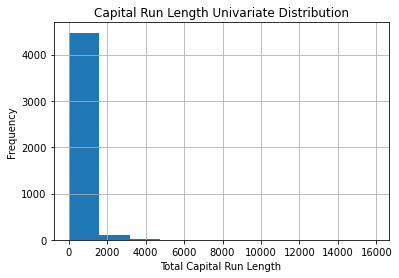

```python
from matplotlib import pyplot as plt
spam["capital_run_length_total:"].hist()
plt.xlabel('Total Capital Run Length')
plt.ylabel('Frequency')
plt.title('Capital Run Length Univariate Distribution')
```

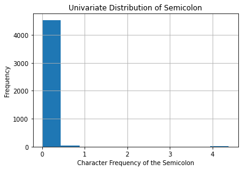

```python
spam['char_freq_;:'].hist()
plt.xlabel('Character Frequency of the Semicolon')
plt.ylabel('Frequency')
plt.title('Univariate Distribution of Semicolon')
```

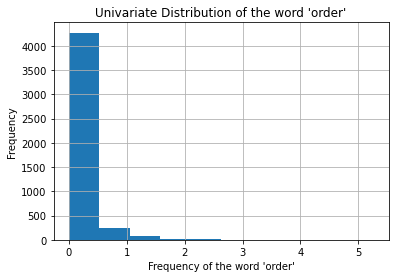

```python
spam['word_freq_order:'].hist()
plt.xlabel("Frequency of the word 'order'")
plt.ylabel('Frequency')
plt.title("Univariate Distribution of the word 'order'")
```

# 4. Name each of the supervised learning models that we have learned thus far that are used to predict dependent variables like "spam".

The variable "spam" is a categorical variable, encoded into 1s and 0s, 1 for something being spam and 0 for something not being spam. Thus, any of our categorical models could help make predictions from this data set. This includes K Nearest Neighbors for Classification, logistic regression, penalized logistic regression, linear support vector machines, decision trees for classification, decision trees for classification with bagging, the gradient booster classifier, and random forests for classification.

*regression for classification...non logistic?*

# 5. Describe the importance of training and test data. Why do we separate data into these subsets?

When we first have a data set, we split it into training and test data because we want to use a training set to build and tune a model, and a test set to estimate the predictive performance of our original model. Usually we randomly split the training and test data, to have an effect of random sampling of data points, so that the test data simulates potentional data that our model would use to make new predictions for y. We then compare with our test data how well our model predicted each y. This helps validate our model, built on the training data, to the real world.

Essentially the subsets allow us to build a model and then test how well that model works before we apply the model into places we do not have both an x and a y. Randomly splitting the data using sampling techniques such as stratification and k-fold will also help keep the training and test data homogenous so that our observations remain under the assumption of being independent and identically distributed.

# 6. What is k-fold cross validation and what do we use it for?

K-fold cross validation is a resampling technique that evaluates generalization of performance. It is more stable than just doing a simple train/test split of the data. It splits the data multiple times into k partitions, called "folds". Then, many models are trained: the first model on the first fold is the test set, and the other folds are used for training. Then the accuracy of each of the folds except for the first is compared to fold 1. Then, this process is repeated by now using fold 2 as a test set and all the others are training. There will be a total of k accuracy values. Train-test-splitting only performs one random split of the data, while CV performs multiple splits, which shows how well the model generalizes to all samples of a dataset. It provides both the best and worst case scenarios when applied to the data, thus helping the data be used more effectively. The cross_val_score function builds these multiple models internally, and cv evaluates how well the model generalizes. As k increases, the bias of the model becomes smaller. Thus this provides a robust metric as to why we would choose one model over another.

# 7. How is k-fold cross validation different from stratified k-fold cross validation?

Stratified k-fold splits the data into k folds but starts with the first one-kth-part of the data. This creates balance with respect to outcome. Essentially, it splits such that the proportions between classes in the data are the same in each fold as they are in the whole dataset. This promotes homogeneity of folds. For example, if 90% of samples are class A and 10% class B, then 90% of each sample will be class A and 10% class B. This homogeneity of folds, due to the ensurance of relative class frequencies with respect to the full sample, makes stratified k-fold more reliable for generalization.

# 8. Choose one model from question four. Split the data into training and test subsets. Build a model with the three variables in the dataset that you think will be good predictors of "spam". Describe why you chose any particular parameters for your model (e.g.- if you used KNN how did you decide to choose a specific value for k). Run the model and evaluate prediction error in two ways: A) On test data directly and B) using k-fold cross-validation.

### KNN Classifier

```python
#Importing things, choosing X/y, doing my split.
from sklearn.model_selection import train_test_split
from sklearn import preprocessing
import numpy as np

y = spam['spam']
X = spam.loc[:, ['word_freq_order:', 'capital_run_length_total:', 'char_freq_;:']]

X_train, X_test, y_train, y_test = train_test_split(X, y, random_state=42)

X.head()
```

|  | word_freq_order: | capital_run_length_total: | char_freq_;: |
| --- | --- | --- | --- |
| 0 | 0.00 | 278 | 0.00 |
| 1 | 0.00 | 1028 | 0.00 |
| 2 | 0.64 | 2259 | 0.01 |
| 3 | 0.31 | 191 | 0.00 |
| 4 | 0.31 | 191 | 0.00 |

```python
#Scaling the data, importing the validation things I'll be using
scaler = preprocessing.StandardScaler().fit(X_train)
X_train_scaled = scaler.transform(X_train)
X_test_scaled = scaler.transform(X_test)

from sklearn.model_selection import KFold
from sklearn.model_selection import cross_val_score
kfold = KFold(n_splits=5)
```

```python
#First model: KNeighborsClassifier, on test data directly.
from sklearn.neighbors import KNeighborsClassifier
knn= KNeighborsClassifier(n_neighbors=9)
knn.fit(X_train_scaled, y_train)
print('Prediction Score on Test Data Directly: {:.2f}'.format(knn.score(X_test_scaled, y_test)))
```

```
Prediction Score on Test Data Directly: 0.72
```

```python
#For choosing certain parameters, above, I choose arbritrary ones to begin with, like n_neighbors= 5. I will use GridSearchCV to choose parameters that have the best generalization.
from sklearn.model_selection import GridSearchCV
from sklearn.pipeline import make_pipeline
from sklearn.preprocessing import StandardScaler

knn_pipe = make_pipeline(StandardScaler(), KNeighborsClassifier())
knn_param_grid = {'kneighborsclassifier__n_neighbors': range(1, 10)}
knn_grid = GridSearchCV(knn_pipe, knn_param_grid).fit(X_train_scaled, y_train)

print("KNN for CLASSIFICATION")
print("Test set Score: {:.2f}".format(knn_grid.score(X_test_scaled, y_test)))
print("Best Parameter: {}".format(knn_grid.best_params_))
```

```
KNN for CLASSIFICATION
Test set Score: 0.72
Best Parameter: {'kneighborsclassifier__n_neighbors': 9}
```

```python
#using kfold
knn_scaled = KNeighborsClassifier().fit(X_train_scaled, y_train)
print("Mean Cross Validation, KFold: {:.2f}".format(np.mean(cross_val_score(knn_scaled, X_train_scaled, y_train, cv=kfold))))
```

```
Mean Cross Validation, KFold: 0.72
```

# 9. Choose a second model from question four. Using the same three variables in the dataset that you think will be good predictors of "spam". Describe why you chose any particular parameters for your model (e.g.- if you used KNN how did you decide to choose a specific value for k). Run the model and evaluate prediction error in two ways: A) On test data directly and B) using k-fold cross-validation. Did this model predict test data better than your previous model?

### Logistic Regression (Unpenalized): Here I am tuning C to be really high to push down the automatic regularization that sklearn does for logistic regression.

```python
from sklearn.linear_model import LogisticRegression

logreg = LogisticRegression(C=1e90).fit(X_train_scaled, y_train)

print("LOGISTIC REGRESSION UNPENALIZED")
print("Training set score: {:.2f}".format(logreg.score(X_train_scaled, y_train)))
print("Test set score: {:.2f}".format(logreg.score(X_test_scaled, y_test)))

# Kfold Cross Validation
print("Mean Cross Validation, KFold: {:.2f}".format(np.mean(cross_val_score(logreg, X_train_scaled, y_train, cv=kfold))))

logreg_predicted_vals = logreg.predict(X_test)

# Organize the model coefficients
logreg_coef = pd.DataFrame(data=logreg.coef_, columns=X.columns, index=['Logistic Regression Coefficients'])
logreg_coef.head()
```

```
LOGISTIC REGRESSION UNPENALIZED
Training set score: 0.69
Test set score: 0.65
Mean Cross Validation, KFold: 0.68
```

|  | word_freq_order: | capital_run_length_total: | char_freq_;: |
| --- | --- | --- | --- |
| Logistic Regression Coefficients | 0.326562 | 0.884294 | -0.353508 |

### Logistic Regression, Penalized: Here I am choosing C=15 because grid search CV maximizes the test score using this parameter.

```python
#Here, I am going to do the penalized logistic regression since the model above did not score as well.
logreg = LogisticRegression(C=15).fit(X_train_scaled, y_train)

print("LOGISTIC REGRESSION PENALIZED")
print("Training set score: {:.2f}".format(logreg.score(X_train_scaled, y_train)))
print("Test set score: {:.2f}".format(logreg.score(X_test_scaled, y_test)))

# Kfold Cross Validation

print("Mean Cross Validation, KFold: {:.2f}".format(np.mean(cross_val_score(logreg, X_train_scaled, y_train, cv=kfold))))

logreg_predicted_vals = logreg.predict(X_test_scaled)

# Organize the model coefficients
logreg_coef = pd.DataFrame(data=logreg.coef_, columns=X.columns, index=['Logistic Regression Coefficients'])
logreg_coef.head()
```

```
LOGISTIC REGRESSION PENALIZED
Training set score: 0.69
Test set score: 0.65
Mean Cross Validation, KFold: 0.68
```

|  | word_freq_order: | capital_run_length_total: | char_freq_;: |
| --- | --- | --- | --- |
| Logistic Regression Coefficients | 0.326933 | 0.879529 | -0.348787 |

```python
#Below i will do some model tuning to see if we can get that test score higher based on parameters.
logreg_pipe = make_pipeline(StandardScaler(), LogisticRegression())


logreg_param_grid = {'logisticregression__C': np.linspace(1, 100, 100)}
logreg_grid = GridSearchCV(logreg_pipe, logreg_param_grid).fit(X_train_scaled, y_train)

print("LOGISTIC REGRESSION (SCALED DATA)")
print("Test set Score: {:.2f}".format(logreg_grid.score(X_test_scaled, y_test)))
print("Best Parameter: {}".format(logreg_grid.best_params_))
```

```
LOGISTIC REGRESSION (SCALED DATA)
Test set Score: 0.65
Best Parameter: {'logisticregression__C': 15.0}
```

```python
pen_logreg_pipe = make_pipeline(StandardScaler(), LogisticRegression(penalty='l2'))


pen_logreg_param_grid = {'logisticregression__C': np.linspace(1, 100, 100)}
pen_logreg_grid = GridSearchCV(pen_logreg_pipe, pen_logreg_param_grid).fit(X_train_scaled, y_train)

print("PENLIZED LOGISTIC REGRESSION (SCALED DATA)")
print("Test set Score: {:.2f}".format(pen_logreg_grid.score(X_test_scaled, y_test)))
print("Best Parameter: {}".format(pen_logreg_grid.best_params_))
```

```
PENLIZED LOGISTIC REGRESSION (SCALED DATA)
Test set Score: 0.65
Best Parameter: {'logisticregression__C': 15.0}
```

# 10. Choose a third model from question four. Using the same three variables in the dataset that you think will be good predictors of "spam". Describe why you chose any particular parameters for your model (e.g.- if you used KNN how did you decide to choose a specific value for k). Run the model and evaluate prediction error in two ways: A) On test data directly and B) using k-fold cross-validation. Did this model predict test data better than your previous models?

```python
from sklearn.svm import SVC
from sklearn.pipeline import make_pipeline

svc = SVC(kernel='rbf',class_weight='balanced')
model = make_pipeline(svc)


param_grid = {'svc__C': [1, 5, 10, 50],
              'svc__gamma': [0.0001, 0.0005, 0.001, 0.005]}
grid = GridSearchCV(model, param_grid)

grid.fit(X_train_scaled, y_train)

print("Best Parameters: {}".format(grid.best_params_))
print(grid.best_estimator_)
print(grid.best_score_)

model = grid.best_estimator_
yfit = model.predict(X_test_scaled)
```

```
Best Parameters: {'svc__C': 50, 'svc__gamma': 0.0005}
Pipeline(steps=[('svc', SVC(C=50, class_weight='balanced', gamma=0.0005))])
0.6982608695652174
```

```python
svc= SVC(kernel= 'rbf', class_weight= 'balanced', C= 50, gamma= .0005)
svc.fit(X_train_scaled, y_train)
print("Test Scores: {}".format(svc.score(X_test_scaled, y_test)))
```

```
Test Scores: 0.6594265855777585
```

```python
print("Mean Cross Validation, KFold: {:.2f}".format(np.mean(cross_val_score(svc, X_train_scaled, y_train, cv=kfold))))
```

```
Mean Cross Validation, KFold: 0.70
```

# 11. Choose a fourth model from question four. Using the same three variables in the dataset that you think will be good predictors of "spam". Describe why you chose any particular parameters for your model (e.g.- if you used KNN how did you decide to choose a specific value for k). Run the model and evaluate prediction error in two ways: A) On test data directly and B) using k-fold cross-validation. Did this model predict test data better than your previous models?

```python
from sklearn.ensemble import RandomForestClassifier

randforest = RandomForestClassifier(n_estimators=200, criterion= 'gini', max_depth= 10)
randforest.fit(X_train_scaled,y_train)
print("Random Forest Test Set Score: {}".format(randforest.score(X_test_scaled, y_test)))
```

```
Random Forest Test Set Score: 0.789748045178106
```

```python
print("Mean Cross Validation, Random Forest: {:.2f}".format(np.mean(cross_val_score(randforest, X_train_scaled, y_train, cv=kfold))))
```

```
Mean Cross Validation, Random Forest: 0.79
```

```python
#have to do grid search CV to choose parameters/tune

forestparam = {'criterion':['gini','entropy'],'max_depth':[4,5,6,7,8,9,10,11,20,30,40,50]}
clf = GridSearchCV(randforest, forestparam, cv=5)
clf.fit(X_train_scaled, y_train)
```

```
GridSearchCV(cv=5, estimator=RandomForestClassifier(n_estimators=200),
             param_grid={'criterion': ['gini', 'entropy'],
                         'max_depth': [4, 5, 6, 7, 8, 9, 10, 11, 20, 30, 40,
                                       50]})
```

```python
clf.score(X_test_scaled, y_test)
```

```
0.7532580364900087
```

```python
clf.best_estimator_
clf.best_params_
```

```
{'criterion': 'gini', 'max_depth': 10}
```

# 12. Now rerun your best model from questions 8 through 11, but this time add three new variables to the model that you think will increase prediction accuracy. Did this model predict test data better than your previous models?

```python
spam.columns
```

```
Index(['word_freq_make:', 'word_freq_address:', 'word_freq_all:',
       'word_freq_3d:', 'word_freq_our:', 'word_freq_over:',
       'word_freq_remove:', 'word_freq_internet:', 'word_freq_order:',
       'word_freq_mail:', 'word_freq_receive:', 'word_freq_will:',
       'word_freq_people:', 'word_freq_report:', 'word_freq_addresses:',
       'word_freq_free:', 'word_freq_business:', 'word_freq_email:',
       'word_freq_you:', 'word_freq_credit:', 'word_freq_your:',
       'word_freq_font:', 'word_freq_000:', 'word_freq_money:',
       'word_freq_hp:', 'word_freq_hpl:', 'word_freq_george:',
       'word_freq_650:', 'word_freq_lab:', 'word_freq_labs:',
       'word_freq_telnet:', 'word_freq_857:', 'word_freq_data:',
       'word_freq_415:', 'word_freq_85:', 'word_freq_technology:',
       'word_freq_1999:', 'word_freq_parts:', 'word_freq_pm:',
       'word_freq_direct:', 'word_freq_cs:', 'word_freq_meeting:',
       'word_freq_original:', 'word_freq_project:', 'word_freq_re:',
       'word_freq_edu:', 'word_freq_table:', 'word_freq_conference:',
       'char_freq_;:', 'char_freq_(:', 'char_freq_[:', 'char_freq_!:',
       'char_freq_$:', 'char_freq_#:', 'capital_run_length_average:',
       'capital_run_length_longest:', 'capital_run_length_total:', 'spam'],
      dtype='object')
```

```python
Xnew= spam.loc[:, ['word_freq_order:', 'capital_run_length_total:', 'char_freq_;:', 'word_freq_font:', 'word_freq_addresses:', 'word_freq_000:']]
```

```python
X_train, X_test, y_train, y_test = train_test_split(Xnew, y, random_state=43)
scaler= preprocessing.StandardScaler().fit(X_train)
X_train_scaled = scaler.transform(X_train)
X_test_scaled = scaler.transform(X_test)
```

```python
randforest1 = RandomForestClassifier(n_estimators=200, criterion= 'entropy', max_depth= 11)
randforest1.fit(X_train_scaled,y_train)
print("Random Forest Test Set Score: {}".format(randforest1.score(X_test_scaled, y_test)))
print("Mean Cross Validation, Random Forest: {:.2f}".format(np.mean(cross_val_score(randforest, X_train_scaled, y_train, cv=kfold))))
```

```
Random Forest Test Set Score: 0.788879235447437
Mean Cross Validation, Random Forest: 0.78
```

```python
forestparam1 = {'criterion':['gini','entropy'],'max_depth':[4,5,6,7,8,9,10,11,20,30,40,50]}
clf1 = GridSearchCV(randforest1, forestparam1, cv=5)
clf1.fit(X_train_scaled, y_train)
clf1.best_params_
```

```
{'criterion': 'entropy', 'max_depth': 11}
```

# 13. Rerun all your other models with this final set of six variables, evaluate prediction error, and choose a final model. Why did you select this model among all of the models that you ran?

## Note I am just running on the k-fold cv case with the best parameters chosen for all models from GridSearchCV. I also only chose penalized logistic regression since penalized and unpenalized in this case produced the same accuracies. We can see the mean cross validation under k-fold is still the highest under Random Forest after using six variables.

```python
knn_scaled = KNeighborsClassifier(n_neighbors=9).fit(X_train_scaled, y_train)
print("Mean Cross Validation, KNN: {:.2f}".format(np.mean(cross_val_score(knn_scaled, X_train_scaled, y_train, cv=kfold))))
print("Mean Cross Validation, Random Forest: {:.2f}".format(np.mean(cross_val_score(randforest, X_train_scaled, y_train, cv=kfold))))
svc.fit(X_train_scaled, y_train)
print("Mean Cross Validation, SVC: {:.2f}".format(np.mean(cross_val_score(svc, X_train_scaled, y_train, cv=kfold))))
logreg = LogisticRegression(C=15).fit(X_train_scaled, y_train)
print("Mean Cross Validation, Logistic Regression: {:.2f}".format(np.mean(cross_val_score(logreg, X_train_scaled, y_train, cv=kfold))))
```

```
Mean Cross Validation, KNN: 0.76
Mean Cross Validation, Random Forest: 0.78
Mean Cross Validation, SVC: 0.74
Mean Cross Validation, Logistic Regression: 0.74
```

## Now checking raw test set scores for all the above models. We can see that KNN does better with more variables, but Random Forest is still the best way to go as it has the highest cross validation and test scores across the board. Random Forests do not seem sensitive to the addition of new variables that may not be fully correlated with the outcome. However, with the addition of even more variables, KNN may start outperforming the Random Forest model.

```python
print ("KNN Test Set Score:{:.2f}".format(knn_scaled.score(X_test_scaled, y_test)))
print("Random Forest Test Set Score: {:.2f}".format(randforest1.score(X_test_scaled, y_test)))
print("SVC Test Set Scores: {:.2f}".format(svc.score(X_test_scaled, y_test)))
print("Penalized Logistic Regression Test Set Score: {:.2f}".format(logreg.score(X_test_scaled, y_test)))
```

```
KNN Test Set Score:0.78
Random Forest Test Set Score: 0.79
SVC Test Set Scores: 0.75
Penalized Logistic Regression Test Set Score: 0.74
```

# 14. What variable that currently is not in your model, if included, would be likely to increase your final model's predictive power? For this answer try to speculate about a variable outside the variables available in the data that would improve you model.

I would include a dummy variable for the presence of hyperlinks or external images. This is usually the case in many spam emails where they try to link the consumer or recipient into buying or clicking on something. This would increase the predictive power because having a link in an email is not extremely correlated with character length or capital letters or other such features we have used. This way, presence of hyperlinks are an omitted variable that could contribute to the prediction power of the model.

# 15. Lastly, you have listed each of the models that we have learned to use to predict dependent variables like spam. List each model we have focused on in class thus far that you could use to evaluate data with a continuous dependent variable.

KNN Neighbors Regressor, Linear Regression, linear regression with ridge, linear regression with lasso, linear regression with an elastic net or other such penalty, support vector machines for regression, decision tree regressors, decision tree regressor with bagging, random forest regression, gradient boosted regression trees